# Explore Google Health Trends intimate partner violence-related search term test runs

One sentence summary about objective of this doc – to explore google health trends for intimate partner violence-related search terms by examining data for 2019 (prior to study period).

Weekly searches at the national level for 2019:

Terms include variations of: “how to text/what is/find abuse hotline number”, “[perpetrator] abuses me”, “how to develop code words to tell children to call 911”, “I feel unsafe/husband/boyfriend/partner makes me feel unsafe”, “abuse/domestic violence hotline/help/emergency line/helpline/support line”, “women’s/domestic violence shelter/ help for abused women”, “how to keep partner/boyfriend/husband calm”, “how to secretly save money”, “how to leave abusive/dangerous relationship/marriage”, “how to protect kinds from domestic violence”

Perpetrators included: husband, boyfriend, ex-boyfriend, ex-husband, ex boyfriend, ex husband, exboyfriend, exhusband, wife, girlfriend, ex-wife, ex-girlfriend, ex wife, ex girlfriend, exwife, exgirlfriend, partner, ex-partner, expartner, ex partner, spouse, ex-spouse, exspouse, ex spouse, ex, significant other

** Note the different y-axis scale for ‘abuse/domestic violence hotline’ searches in first set of plots.

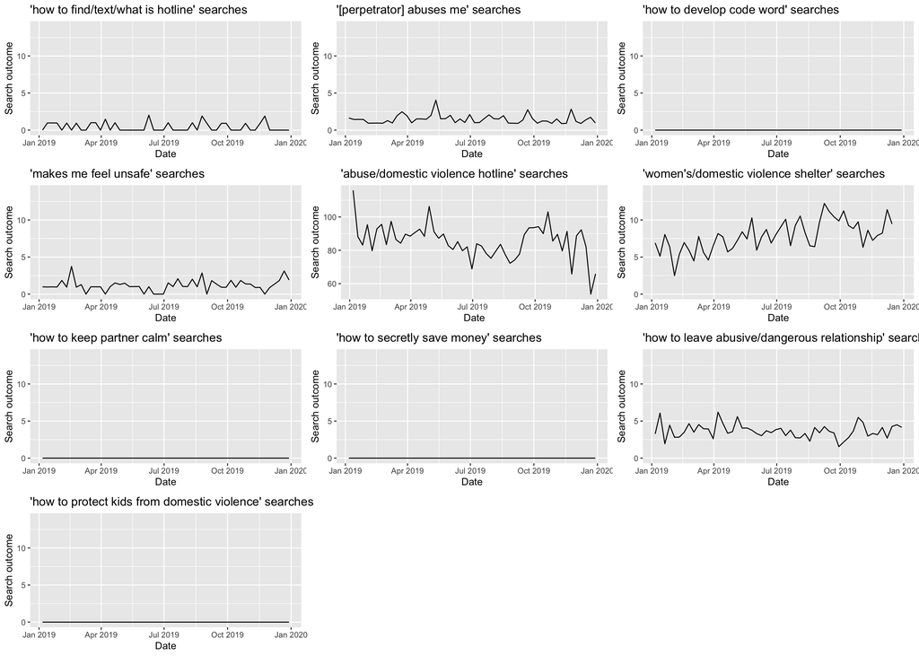

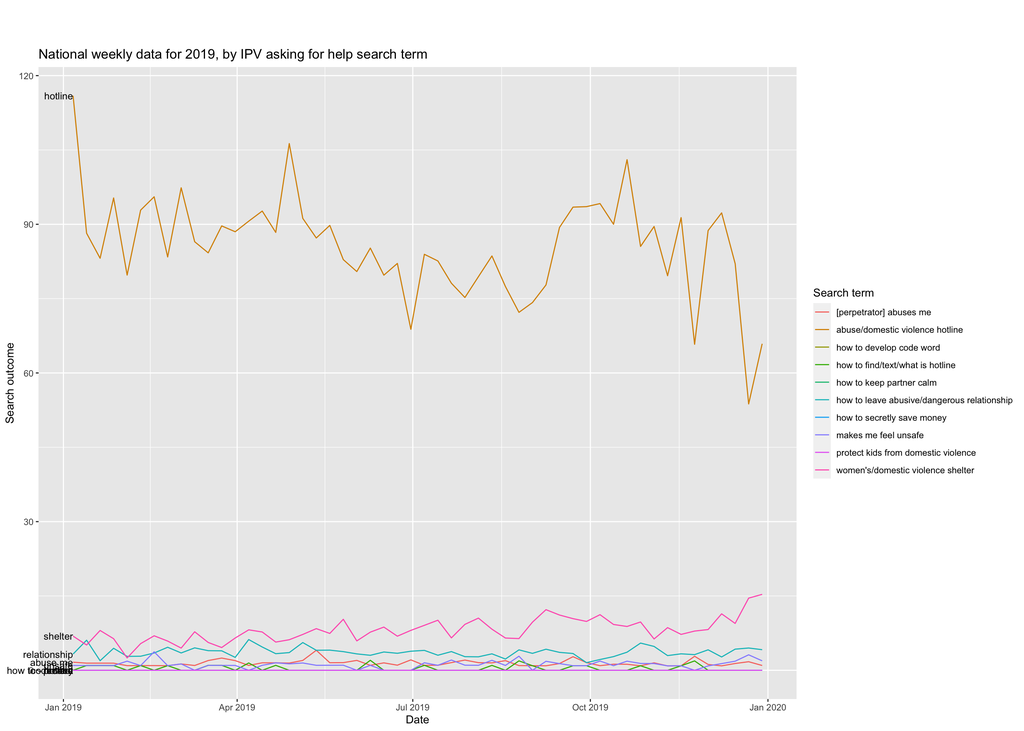

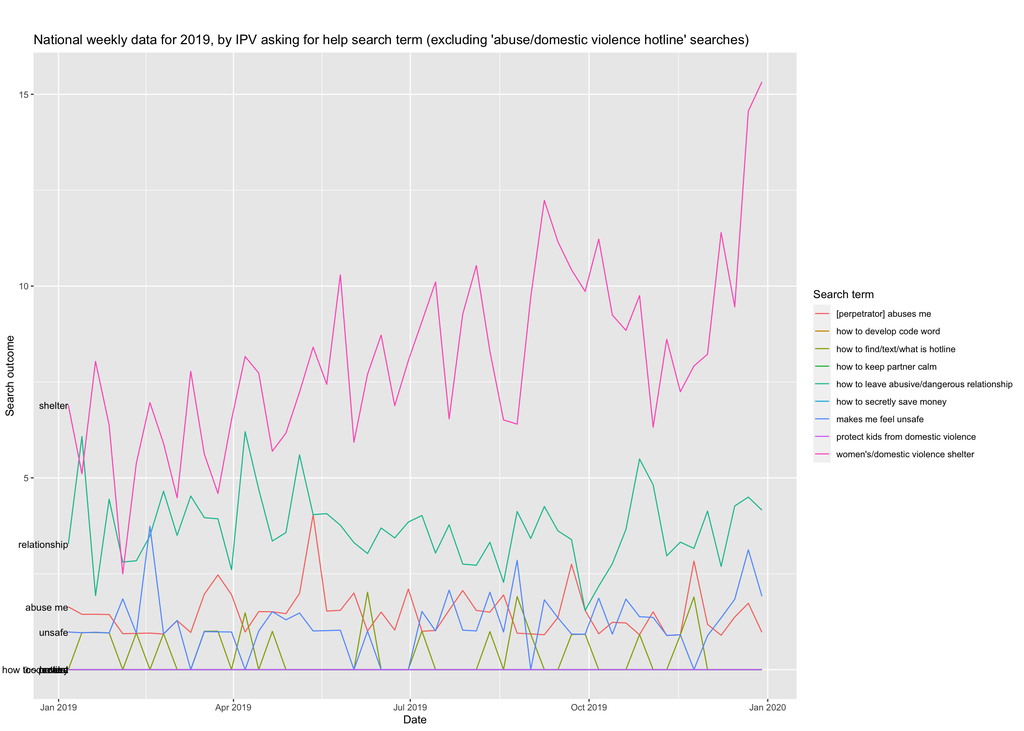

Daily searches at the national level for 2019 for “abuse/domestic violence hotline/help/emergency line/helpline/support line” - to examine for expected spikes on days when people drink more (e.g., New Years) as a data validity check

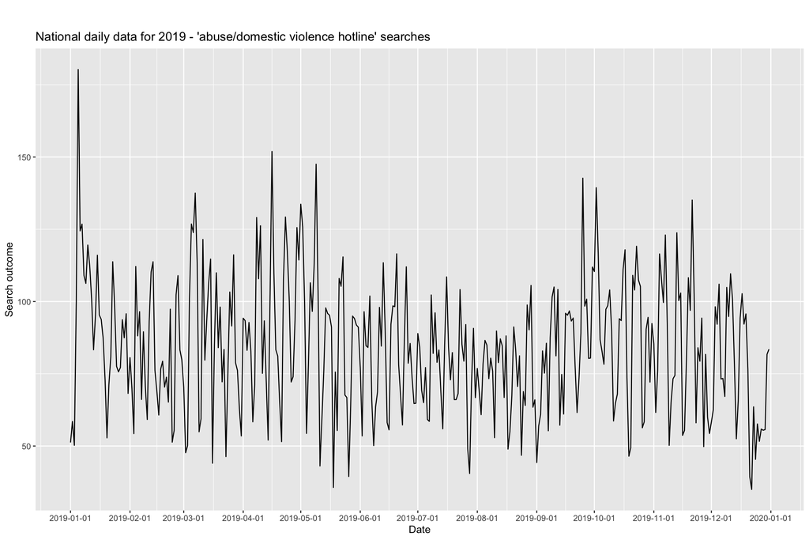